# Visualizations - STARTER

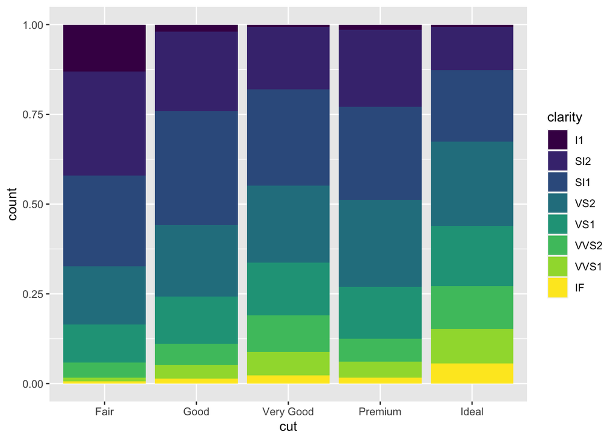

```r
ggplot(data = diamonds,
       aes(x = cut,
           fill = clarity)) +
  geom_bar(position = "fill")
```

## Line plots

### geom_line()

```r
data_sun <- data.frame(year = c(1700:1988),
                       sunspots = as.vector(sunspot.year))
glimpse(data_sun)
```

```
Rows: 289
Columns: 2
$ year     <int> 1700, 1701, 1702, 1703, 1704, 1705, 1706, 1707, 1708, 1709, 1…
$ sunspots <dbl> 5, 11, 16, 23, 36, 58, 29, 20, 10, 8, 3, 0, 0, 2, 11, 27, 47,…
```

```r
ggplot(data = data_sun)
```

## Facets

### facet_wrap()

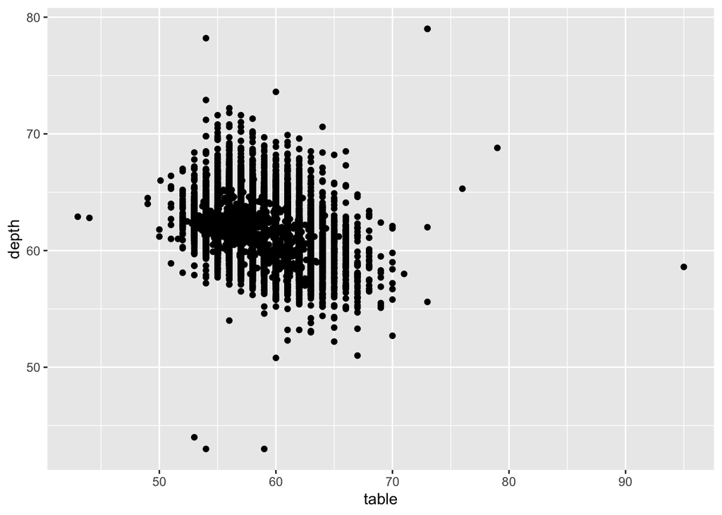

```r
ggplot(data = diamonds,
       aes(x = table,
           y = depth)) +
  geom_point()
```

### Controlling rows and columns

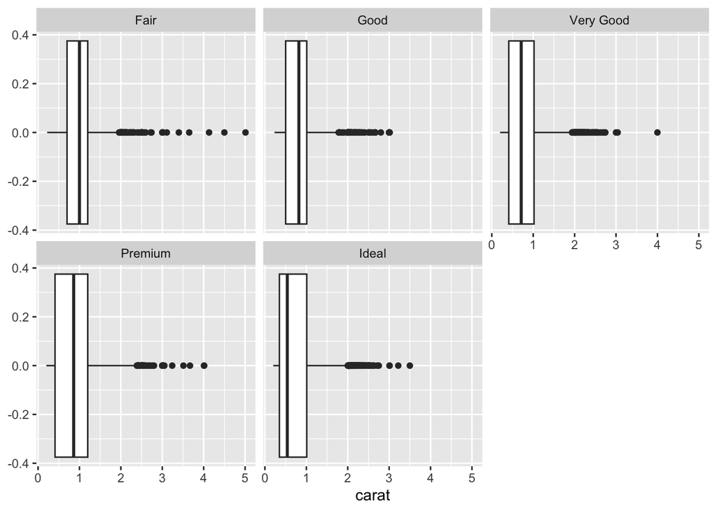

```r
ggplot(data = diamonds,
       aes(x = carat)) +
  geom_boxplot() +
  facet_wrap(~ cut)
```

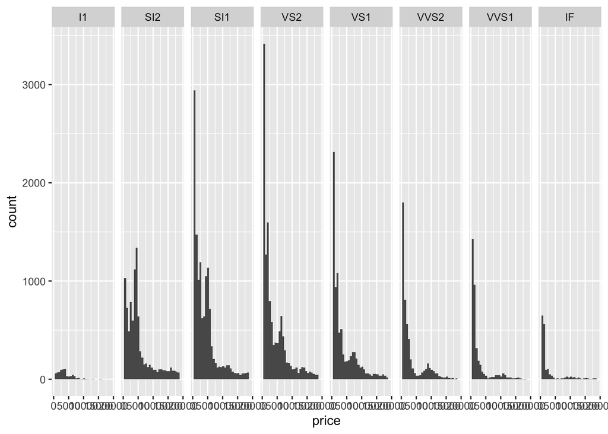

```r
ggplot(data = diamonds,
       aes(x = price)) +
  geom_histogram() +
  facet_wrap(~ clarity,
             nrow = 1)
```

### Scales for facets

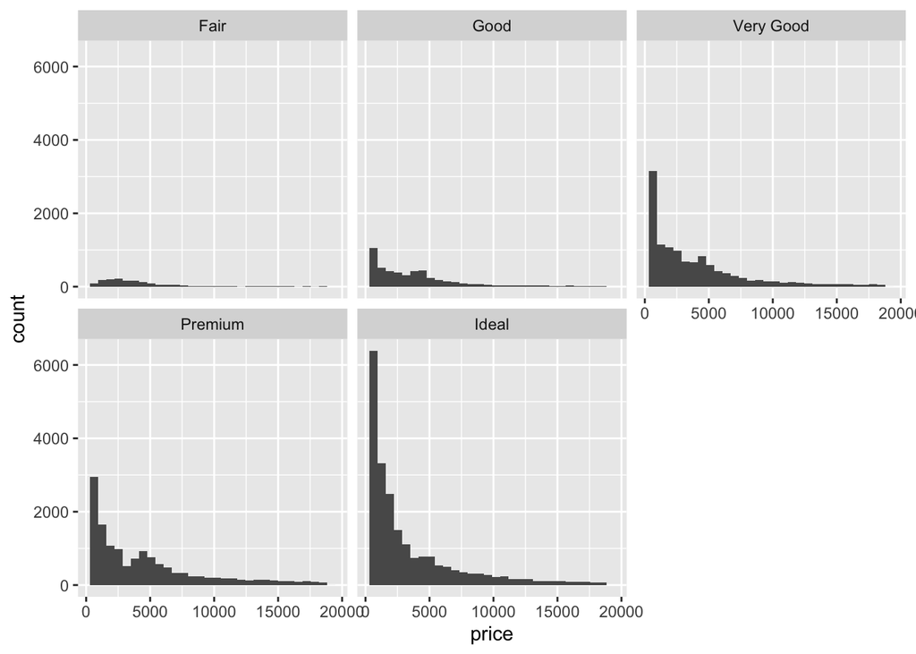

```r
ggplot(data = diamonds,
       aes(x = price)) +
  geom_histogram() +
  facet_wrap(~ cut)
```

### Exercise

- Using the code chunk below, create a boxplots using the *iris* dataset that includes the following features:
  1. Plots `Sepal.Length` faceted by `Species`;
  2. Stack the facets vertically to emphasize the differences between each Species;
  3. Think about if we want to adjust the scales of the panel, why or why not?
- Note that we made this plot previously with comparitive boxplots by specifying `aes(y = Species)`; so this is an alternative.

### facet_grid()

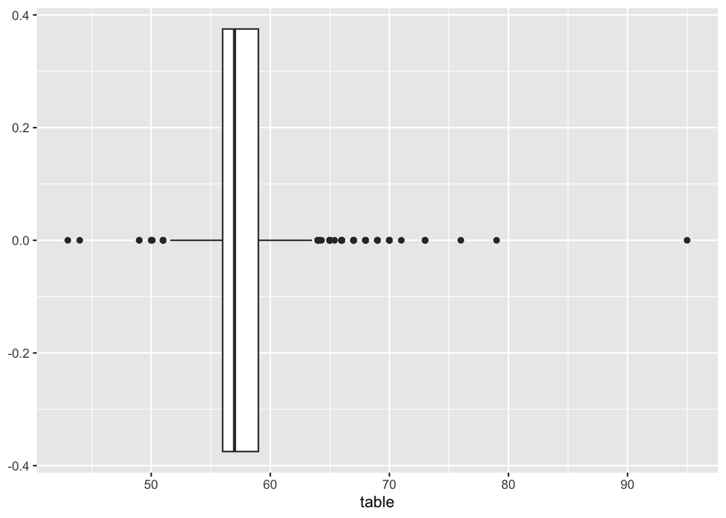

```r
ggplot(data = diamonds,
       aes(x = table)) +
  geom_boxplot()
```

### Exercise

- Using the code chunk below, create scatterplots of `carat` vs `price` that is colored by `cut` and facetted by `color` and `clarity`. Try a few different options for `scales` to see how they affect the plot.

```r
# create a sample from of data with fewer levels (variety from ordinal scale of each)
diamonds_sample <- diamonds %>%
  filter(cut %in% unique(diamonds$cut)[c(1,3,5)],
         color %in% unique(diamonds$color)[c(1,4,7)],
         clarity %in% unique(diamonds$clarity)[c(1,4,8)]) %>%
  sample_n(size = 5000)
```

```r
diamonds_sample
```

```
# A tibble: 5,000 × 10
   carat cut   color clarity depth table price     x     y     z
   <dbl> <ord> <ord> <ord>   <dbl> <dbl> <int> <dbl> <dbl> <dbl>
 1  0.33 Ideal E     VS2      61.6    55   873  4.46  4.5   2.76
 2  0.91 Good  E     SI2      63.9    61  3538  6.03  6.09  3.87
 3  1.01 Ideal D     SI2      62.6    56  4872  6.4   6.34  3.99
 4  2.21 Ideal H     SI2      61.9    56 13615  8.4   8.36  5.19
 5  0.3  Ideal D     VS2      61.8    55   911  4.34  4.3   2.67
 6  0.53 Ideal D     SI2      60.4    57  1314  5.26  5.3   3.19
 7  1.01 Good  E     VS2      63.3    60  6399  6.3   6.33  4
 8  0.56 Ideal D     VS2      61.1    56  1963  5.3   5.33  3.25
 9  0.43 Ideal D     VS2      61.8    56  1129  4.83  4.81  2.98
10  0.5  Ideal E     VS2      61.6    56  1554  5.1   5.13  3.15
# ℹ 4,990 more rows
```

## Density histograms and density curves

### Density histograms

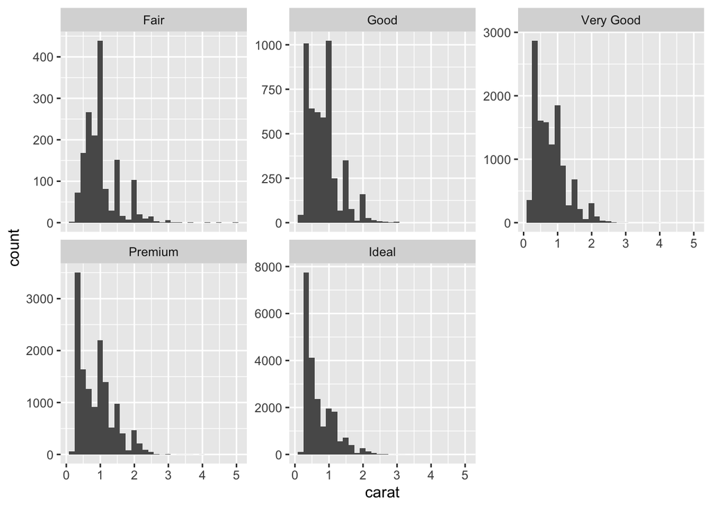

```r
ggplot(data = diamonds,
       aes(x = carat)) +
  geom_histogram() +
  facet_wrap(~ cut,
             scales = "free_y")
```

### Density curves

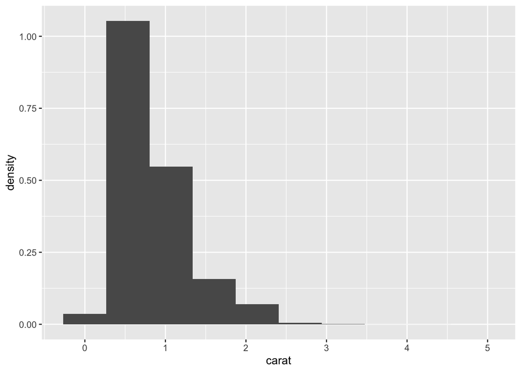

```r
ggplot(data = diamonds,
       aes(x = carat,
           y = after_stat(density))) +
  geom_histogram(bins = 10)
```

[figure not shown]

```r
ggplot(data = diamonds,
       aes(x = carat))
```

### Multiple density curves

[output not shown]

### Amount of smoothing

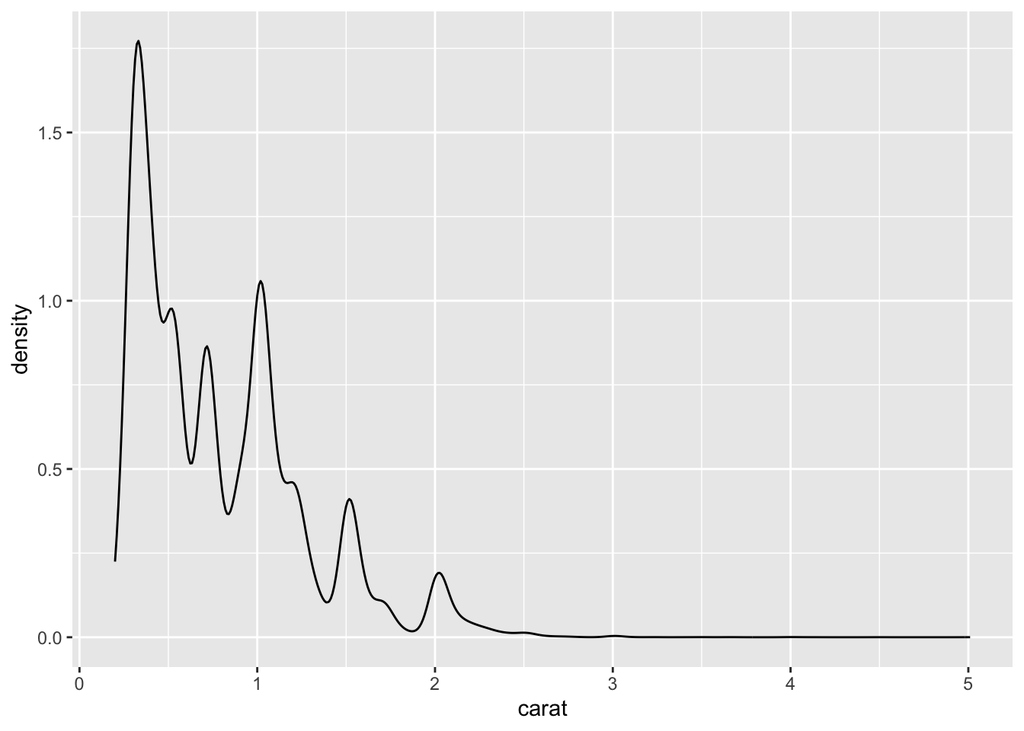

```r
ggplot(data = diamonds,
       aes(x = carat)) +
  geom_density()
```

### Exercise

- Using the code chunk below, use the *iris* dataset to do the following:
  1. Create density curves of a `Petal.Length` colored by each `Species`;
  2. Adjust the amount of smoothing to find a level that shows the overall trends well with some detail, but that is not overly exact (it’s a balance);
  3. Add `fill = Species` in the `aes()` statement to see the result of this;
  4. Notice how the colors are completely opaque (not “see through”). To make them more transparent, add the following option locally `geom_density(alpha = 0.5)`. Try a few different values (`0 \le alpha \le 1`) to see the result. Note that this option can also be used with lots other `geom_*()` as well.
  5. What does this plot tell us about the petal lengths of the different species?

## Application

### Recreating

```r
# load basketball data
# TO DO FIRST:
# -> 1) create a folder named "data" in the same location where you saved this file and save the file "data-bsu-game.RData" in it
# -> 2) remove eval = FALSE from the code chunk header
load("data/data-bsu-game.RData")
data_bsu_game
```